# Parallel processing in R

01/11/2021

## What is Parallel processing?

Is a type of computation in which many calculations or process are carried out simultaneously.

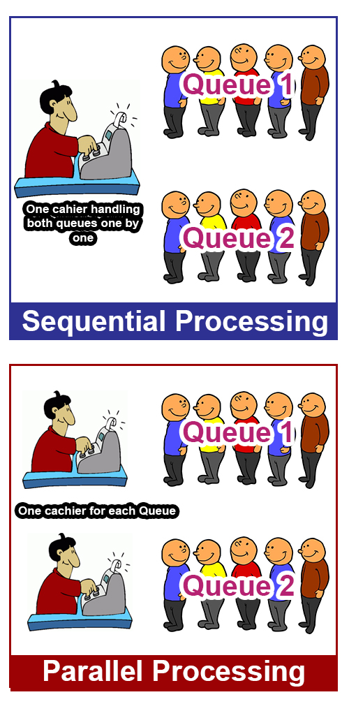

## Parallel Packages in R

How we do this?

Multi Core Processors. Computers today have multiple cores on them.

- `Parallel` [R Baseline]
- `Rmpi`
- `future`
- `Foreach`
- Etc.

## The Parallel package

The `parallel` package is now part of the core distribution of R. It includes a number of different mechanisms to enable you to exploit parallelism utilizing the multiple cores in your processor(s) as well as compute the resources distributed across a network as a cluster of machines.

However, in this talk, we will stick to making the most of the resources available on the machine on which you are running R.

## Some steps

**How many cores do you have?**

```r
# Load the package
library(parallel)
detectCores()
```

```
## [1] 8
```

**Starting clusters**

```r
cl <- makeCluster(2)
```

**Sending libraries to clusters**

```r
clusterEvalQ(cl, {
  library(tidyverse)
})
```

```
## [[1]]
##  [1] "forcats"   "stringr"   "dplyr"     "purrr"     "readr"     "tidyr"
##  [7] "tibble"    "ggplot2"   "tidyverse" "stats"     "graphics"  "grDevices"
## [13] "utils"     "datasets"  "methods"   "base"
##
## [[2]]
##  [1] "forcats"   "stringr"   "dplyr"     "purrr"     "readr"     "tidyr"
##  [7] "tibble"    "ggplot2"   "tidyverse" "stats"     "graphics"  "grDevices"
## [13] "utils"     "datasets"  "methods"   "base"
```

**Sending variables and functions to clusters**

```r
a <- 2
square <- function(num) num**2

clusterExport(cl, c("a", "square"))

# To test if it was received I run another EvalQ
clusterEvalQ(cl, {
  print(c(a, square(a)))
})
```

```
## [[1]]
## [1] 2 4
##
## [[2]]
## [1] 2 4
```

**Stopping a cluster**

```r
stopCluster(cl)
```

## Example of time saved

Making the computer sleeps 3 sec before running anything, repeating this 5 times…

**Running in series**

```r
ptm <- proc.time()
for (i in 1:5) Sys.sleep(3)
print(proc.time()-ptm)
```

```
##    user  system elapsed
##    0.02    0.00   15.23
```

**Running in parallel**

```r
library(parallel)
ptm <- proc.time()
cl <- makeCluster(8)
invisible(parSapply(cl, rep(3,5), Sys.sleep)) #invisible here just hides the null list from Sapply
stopCluster(cl)
print(proc.time()-ptm)
```

```
##    user  system elapsed
##    0.05    0.11    5.39
```

## Further reading

[Parallel processing in R](https://www.youtube.com/watch?app=desktop&v=EHoTFOW1WjU) by Hadley Wickham

[Parallel R](http://amzn.com/B005Z29QT4) by Q. Ethan McCallum and Stephen Weston.

[Parallel Computing for Data Science](http://amzn.com/1466587016) by Norm Matloff.

[Parallelization in R](https://www.youtube.com/watch?v=FF5jOZsdMrA&t=1532s) talk by Victor Feagins with real-world coding examples.